# ml_project_dataset_24months

### 3.2.3 Regression Models with Interaction

We had identified 2 variables that showed potential interaction with occupation_type, and 2 with flag_own_realty, we look at these now to determine whether interactions should be included in the model.

```r
lm.fit.interact.1 <- update(lm.fit.occ.realty, . ~ . + occupation_type:amt_income_total)
# drop1(lm.fit.interact.1, test = "F")   # insignificant interaction

lm.fit.interact.2 <- update(lm.fit.occ.realty, . ~ . + occupation_type:name_education_type)
# drop1(lm.fit.interact.2, test = "F")   # insignificant interaction

lm.fit.interact.3 <- update(lm.fit.occ.realty, . ~ . + flag_own_realty:age_years)
# drop1(lm.fit.interact.3, test = "F")   # insignificant interaction

lm.fit.interact.4 <- update(lm.fit.occ.realty, . ~ . + flag_own_realty:cnt_fam_members)
drop1(lm.fit.interact.4, test = "F")   # slight interaction
```

```
## Single term deletions
##
## Model:
## percent_good ~ occupation_type + flag_own_realty + flag_own_realty:cnt_fam_members
##                                 Df Sum of Sq     RSS   AIC F value   Pr(>F)
## <none>                                       8702107 54971
## occupation_type                 18     39167 8741274 54970  1.9529 0.009159 **
## flag_own_realty:cnt_fam_members  2      6002 8708109 54972  2.6935 0.067707 .
## ---
## Signif. codes:  0 '***' 0.001 '**' 0.01 '*' 0.05 '.' 0.1 ' ' 1
```

```r
anova(lm.fit.occ.realty, lm.fit.interact.4)
```

```
## Analysis of Variance Table
##
## Model 1: percent_good ~ occupation_type + flag_own_realty
## Model 2: percent_good ~ occupation_type + flag_own_realty + flag_own_realty:cnt_fam_members
##   Res.Df     RSS Df Sum of Sq      F  Pr(>F)
## 1   7812 8708109
## 2   7810 8702107  2    6002.3 2.6935 0.06771 .
## ---
## Signif. codes:  0 '***' 0.001 '**' 0.01 '*' 0.05 '.' 0.1 ' ' 1
```

Here there is only weak evidence that the flag_own_realty:cnt_fam_members interaction plays a role.

## 3.3 Measures of Fit

To quantify the goodness of fit, we look at the R^2 and adjusted R^2 values:

| Fit Value | occupation_type | occupation_type + flag_own_realty | occupation_type + flag_own_realty + flag_own_realty:cnt_fam_members |
| --- | --- | --- | --- |
| R^2 | 0.00446 | 0.00498 | 0.00567 |
| adj R^2 | 0.00217 | 0.00256 | 0.00299 |

We see that the model with interaction has the best R^2 value, however, taking into account the differing complexity of the models, which still shows a slightly higher adjusted R^2, but not by much.

## 3.4 Fitted values and Residuals

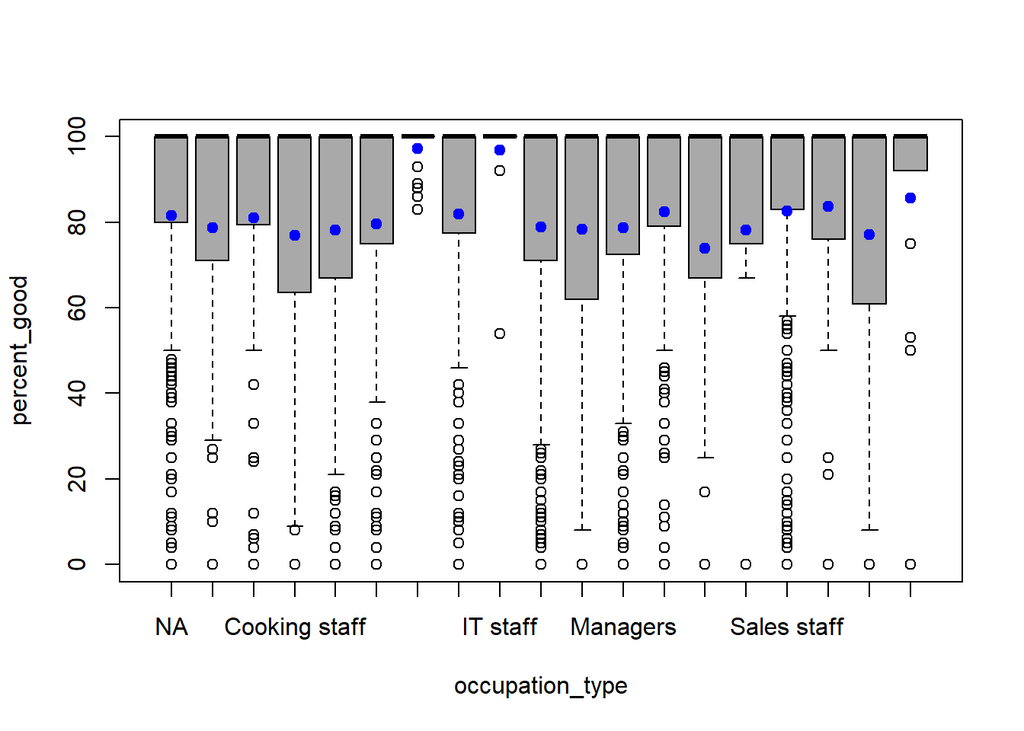

```r
fitted.credit <- fitted(lm.fit.occupation)

plot(percent_good ~ occupation_type, data = df.cc.new, col = "darkgray")
points(fitted.credit ~ occupation_type, data = df.cc.new, col = "blue", pch = 19)
```

## 3.5 Predicted values

```r
set.seed(1)
indices <- createDataPartition(df.cc$percent_good, p=.85, list=F)
# train <- df.cc %>% slice(indices)
test_in <- df.cc %>% slice(-indices) %>% select(-customer_status_good, -percent_good)
test_true <- df.cc %>% slice(-indices) %>% select(percent_good)
```

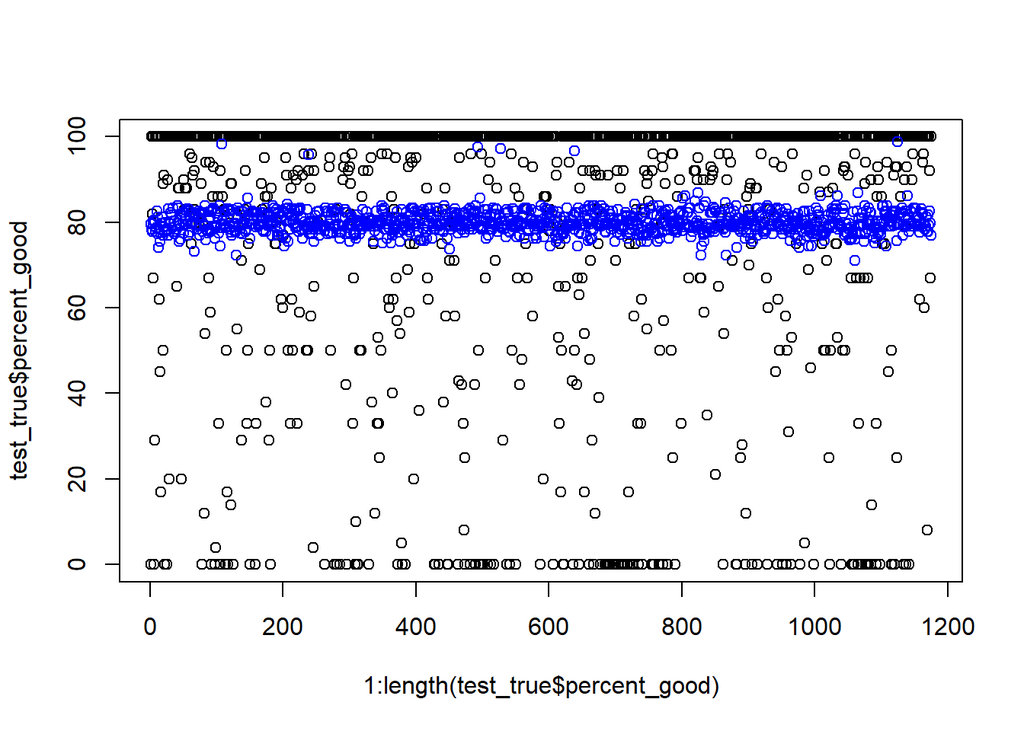

```r
pred.credit <- predict(object = lm.fit.interact.4, newdata = test_in)

plot(x = 1:length(test_true$percent_good), y = test_true$percent_good)
points(x = 1:length(pred.credit), y = pred.credit, col = "blue")
```